# Assignment 5

Kari Roynesdal

10/07/2020

remotes::install_github(“walkerke/tidycensus”)

```r
library(tidycensus)
library(tidyverse)
library(knitr)
library(jtools)
library(interactions)
library(ggstance)
```

```r
Suffolk_tract_household_data <- read_csv("Suffolk_tracts_households.csv")
```

## Initial Regression Model

I decided to adjust some of my variables from last week, so that I could compare the significance of different household types with percent home ownership.

**Dependent Variable**:

Percent Owner-Occupied Households

**Independent Variables**:

The majority racial/ethnic identity

The median age of residents

Total population of the tract

Household Types:

Female Households with No Husband and No Children Under 18 years old

Female Households with No Husband and Children Under 6 years old

Husband and Wife Households with Children Under 6 years old

Households with Two Male Partners with Children Under 18 years old

Households with Two Female Partners with Children Under 18 years old

```r
model1 <- lm(pct_own ~ med_age + tot_pop + majority_race_eth + hh_female_nohusband_nochildrenunder18 +  hh_female_nohusband_childrenunder6yr + hh_husband_wife_fam_childrenunder6yr + hh_unmarriedmale_malepartner_childrenunder18 + hh_unmarriedfemale_femalepartner_childrenunder18,
            data = Suffolk_tract_household_data)
summary(model1)
```

```
##
## Call:
## lm(formula = pct_own ~ med_age + tot_pop + majority_race_eth +
##     hh_female_nohusband_nochildrenunder18 + hh_female_nohusband_childrenunder6yr +
##     hh_husband_wife_fam_childrenunder6yr + hh_unmarriedmale_malepartner_childrenunder18 +
##     hh_unmarriedfemale_femalepartner_childrenunder18, data = Suffolk_tract_household_data)
##
## Residuals:
##       Min        1Q    Median        3Q       Max
## -0.275027 -0.064920  0.008098  0.055354  0.304941
##
## Coefficients:
##                                                    Estimate Std. Error t value
## (Intercept)                                      -2.008e-01  5.189e-02  -3.870
## med_age                                           1.520e-02  1.296e-03  11.731
## tot_pop                                          -1.581e-05  8.035e-06  -1.968
## majority_race_ethhispanic                        -5.812e-02  2.908e-02  -1.998
## majority_race_ethnh_asian                        -3.355e-01  6.699e-02  -5.009
## majority_race_ethnh_black                        -2.221e-02  3.216e-02  -0.690
## majority_race_ethNone                            -2.409e-02  2.134e-02  -1.129
## hh_female_nohusband_nochildrenunder18             6.377e-04  1.992e-04   3.201
## hh_female_nohusband_childrenunder6yr             -2.321e-03  4.580e-04  -5.068
## hh_husband_wife_fam_childrenunder6yr              1.009e-03  2.934e-04   3.440
## hh_unmarriedmale_malepartner_childrenunder18      1.169e-02  5.710e-03   2.047
## hh_unmarriedfemale_femalepartner_childrenunder18  7.010e-03  2.487e-03   2.819
##                                                  Pr(>|t|)
## (Intercept)                                      0.000151 ***
## med_age                                           < 2e-16 ***
## tot_pop                                          0.050595 .
## majority_race_ethhispanic                        0.047140 *
## majority_race_ethnh_asian                        1.27e-06 ***
## majority_race_ethnh_black                        0.490788
## majority_race_ethNone                            0.260490
## hh_female_nohusband_nochildrenunder18            0.001611 **
## hh_female_nohusband_childrenunder6yr             9.72e-07 ***
## hh_husband_wife_fam_childrenunder6yr             0.000718 ***
## hh_unmarriedmale_malepartner_childrenunder18     0.042060 *
## hh_unmarriedfemale_femalepartner_childrenunder18 0.005336 **
## ---
## Signif. codes:  0 '***' 0.001 '**' 0.01 '*' 0.05 '.' 0.1 ' ' 1
##
## Residual standard error: 0.09184 on 185 degrees of freedom
## Multiple R-squared:  0.7472, Adjusted R-squared:  0.7322
## F-statistic: 49.71 on 11 and 185 DF,  p-value: < 2.2e-16
```

### A Log Transformation

I think that a percentage increase for median age may be more relevant for my model at the neighborhood level. I am going to log-transform my median age variable to see if it improves the model fit.

```r
model2 <- lm(pct_own ~ log(med_age) + tot_pop + majority_race_eth + hh_female_nohusband_nochildrenunder18 +  hh_female_nohusband_childrenunder6yr + hh_husband_wife_fam_childrenunder6yr + hh_unmarriedmale_malepartner_childrenunder18 + hh_unmarriedfemale_femalepartner_childrenunder18,
            data = Suffolk_tract_household_data)
summary(model2)
```

```
##
## Call:
## lm(formula = pct_own ~ log(med_age) + tot_pop + majority_race_eth +
##     hh_female_nohusband_nochildrenunder18 + hh_female_nohusband_childrenunder6yr +
##     hh_husband_wife_fam_childrenunder6yr + hh_unmarriedmale_malepartner_childrenunder18 +
##     hh_unmarriedfemale_femalepartner_childrenunder18, data = Suffolk_tract_household_data)
##
## Residuals:
##      Min       1Q   Median       3Q      Max
## -0.28125 -0.06203  0.00393  0.05577  0.28899
##
## Coefficients:
##                                                    Estimate Std. Error t value
## (Intercept)                                      -1.599e+00  1.745e-01  -9.164
## log(med_age)                                      5.483e-01  4.837e-02  11.336
## tot_pop                                          -8.586e-06  8.595e-06  -0.999
## majority_race_ethhispanic                        -6.178e-02  2.947e-02  -2.097
## majority_race_ethnh_asian                        -3.396e-01  6.800e-02  -4.994
## majority_race_ethnh_black                        -2.672e-02  3.257e-02  -0.820
## majority_race_ethNone                            -2.970e-02  2.158e-02  -1.376
## hh_female_nohusband_nochildrenunder18             5.166e-04  2.075e-04   2.489
## hh_female_nohusband_childrenunder6yr             -2.318e-03  4.649e-04  -4.985
## hh_husband_wife_fam_childrenunder6yr              6.689e-04  3.114e-04   2.148
## hh_unmarriedmale_malepartner_childrenunder18      1.135e-02  5.794e-03   1.959
## hh_unmarriedfemale_femalepartner_childrenunder18  7.476e-03  2.519e-03   2.968
##                                                  Pr(>|t|)
## (Intercept)                                       < 2e-16 ***
## log(med_age)                                      < 2e-16 ***
## tot_pop                                            0.3191
## majority_race_ethhispanic                          0.0374 *
## majority_race_ethnh_asian                        1.36e-06 ***
## majority_race_ethnh_black                          0.4131
## majority_race_ethNone                              0.1704
## hh_female_nohusband_nochildrenunder18              0.0137 *
## hh_female_nohusband_childrenunder6yr             1.42e-06 ***
## hh_husband_wife_fam_childrenunder6yr               0.0330 *
## hh_unmarriedmale_malepartner_childrenunder18       0.0516 .
## hh_unmarriedfemale_femalepartner_childrenunder18   0.0034 **
## ---
## Signif. codes:  0 '***' 0.001 '**' 0.01 '*' 0.05 '.' 0.1 ' ' 1
##
## Residual standard error: 0.09317 on 185 degrees of freedom
## Multiple R-squared:  0.7398, Adjusted R-squared:  0.7244
## F-statistic: 47.83 on 11 and 185 DF,  p-value: < 2.2e-16
```

### Adding an Interaction Term

I want to see how median age affects two of my variables, Female Households with Children under 6 years and Female Households with No Children under 18:

```r
model3 <- lm(pct_own ~ med_age + tot_pop + majority_race_eth + hh_female_nohusband_nochildrenunder18 +  hh_female_nohusband_childrenunder6yr + hh_husband_wife_fam_childrenunder6yr + hh_unmarriedmale_malepartner_childrenunder18 + hh_unmarriedfemale_femalepartner_childrenunder18 + hh_female_nohusband_nochildrenunder18:med_age + hh_female_nohusband_childrenunder6yr:med_age,
            data = Suffolk_tract_household_data)
summary(model3)
```

```
##
## Call:
## lm(formula = pct_own ~ med_age + tot_pop + majority_race_eth +
##     hh_female_nohusband_nochildrenunder18 + hh_female_nohusband_childrenunder6yr +
##     hh_husband_wife_fam_childrenunder6yr + hh_unmarriedmale_malepartner_childrenunder18 +
##     hh_unmarriedfemale_femalepartner_childrenunder18 + hh_female_nohusband_nochildrenunder18:med_age +
##     hh_female_nohusband_childrenunder6yr:med_age, data = Suffolk_tract_household_data)
##
## Residuals:
##      Min       1Q   Median       3Q      Max
## -0.27348 -0.06244  0.00584  0.05334  0.30628
##
## Coefficients:
##                                                    Estimate Std. Error t value
## (Intercept)                                      -1.937e-01  6.336e-02  -3.057
## med_age                                           1.496e-02  1.606e-03   9.316
## tot_pop                                          -1.472e-05  8.026e-06  -1.834
## majority_race_ethhispanic                        -6.174e-02  2.898e-02  -2.131
## majority_race_ethnh_asian                        -3.350e-01  6.650e-02  -5.038
## majority_race_ethnh_black                        -1.684e-02  3.204e-02  -0.526
## majority_race_ethNone                            -1.636e-02  2.150e-02  -0.761
## hh_female_nohusband_nochildrenunder18            -1.225e-03  1.051e-03  -1.166
## hh_female_nohusband_childrenunder6yr              5.675e-03  3.665e-03   1.548
## hh_husband_wife_fam_childrenunder6yr              9.901e-04  2.946e-04   3.361
## hh_unmarriedmale_malepartner_childrenunder18      1.114e-02  5.722e-03   1.946
## hh_unmarriedfemale_femalepartner_childrenunder18  7.093e-03  2.479e-03   2.861
## med_age:hh_female_nohusband_nochildrenunder18     5.571e-05  2.996e-05   1.859
## med_age:hh_female_nohusband_childrenunder6yr     -2.499e-04  1.138e-04  -2.196
##                                                  Pr(>|t|)
## (Intercept)                                      0.002569 **
## med_age                                           < 2e-16 ***
## tot_pop                                          0.068237 .
## majority_race_ethhispanic                        0.034451 *
## majority_race_ethnh_asian                        1.12e-06 ***
## majority_race_ethnh_black                        0.599861
## majority_race_ethNone                            0.447842
## hh_female_nohusband_nochildrenunder18            0.244991
## hh_female_nohusband_childrenunder6yr             0.123233
## hh_husband_wife_fam_childrenunder6yr             0.000946 ***
## hh_unmarriedmale_malepartner_childrenunder18     0.053190 .
## hh_unmarriedfemale_femalepartner_childrenunder18 0.004712 **
## med_age:hh_female_nohusband_nochildrenunder18    0.064567 .
## med_age:hh_female_nohusband_childrenunder6yr     0.029374 *
## ---
## Signif. codes:  0 '***' 0.001 '**' 0.01 '*' 0.05 '.' 0.1 ' ' 1
##
## Residual standard error: 0.09115 on 183 degrees of freedom
## Multiple R-squared:  0.7537, Adjusted R-squared:  0.7362
## F-statistic: 43.08 on 13 and 183 DF,  p-value: < 2.2e-16
```

I will test another model showing all of these variations for my households variables, using an interaction term of median age:

```r
model4 <- lm(pct_own ~ log(med_age) + tot_pop + majority_race_eth + hh_female_nohusband_nochildrenunder18 +  hh_female_nohusband_childrenunder6yr + hh_husband_wife_fam_childrenunder6yr + hh_unmarriedmale_malepartner_childrenunder18 + hh_unmarriedfemale_femalepartner_childrenunder18 + hh_female_nohusband_nochildrenunder18:med_age + hh_female_nohusband_childrenunder6yr:med_age + hh_husband_wife_fam_childrenunder6yr:med_age + hh_unmarriedmale_malepartner_childrenunder18:med_age + hh_unmarriedfemale_femalepartner_childrenunder18:med_age ,
            data = Suffolk_tract_household_data)
summary(model4)
```

```
##
## Call:
## lm(formula = pct_own ~ log(med_age) + tot_pop + majority_race_eth +
##     hh_female_nohusband_nochildrenunder18 + hh_female_nohusband_childrenunder6yr +
##     hh_husband_wife_fam_childrenunder6yr + hh_unmarriedmale_malepartner_childrenunder18 +
##     hh_unmarriedfemale_femalepartner_childrenunder18 + hh_female_nohusband_nochildrenunder18:med_age +
##     hh_female_nohusband_childrenunder6yr:med_age + hh_husband_wife_fam_childrenunder6yr:med_age +
##     hh_unmarriedmale_malepartner_childrenunder18:med_age + hh_unmarriedfemale_femalepartner_childrenunder18:med_age,
##     data = Suffolk_tract_household_data)
##
## Residuals:
##       Min        1Q    Median        3Q       Max
## -0.280739 -0.057959  0.002412  0.054555  0.290229
##
## Coefficients:
##                                                            Estimate Std. Error
## (Intercept)                                              -1.623e+00  2.250e-01
## log(med_age)                                              5.545e-01  6.248e-02
## tot_pop                                                  -5.905e-06  8.930e-06
## majority_race_ethhispanic                                -6.874e-02  3.114e-02
## majority_race_ethnh_asian                                -3.497e-01  7.043e-02
## majority_race_ethnh_black                                -1.958e-02  3.256e-02
## majority_race_ethNone                                    -2.065e-02  2.191e-02
## hh_female_nohusband_nochildrenunder18                    -1.795e-03  1.282e-03
## hh_female_nohusband_childrenunder6yr                      7.794e-03  4.068e-03
## hh_husband_wife_fam_childrenunder6yr                      4.868e-04  1.553e-03
## hh_unmarriedmale_malepartner_childrenunder18              3.060e-02  4.405e-02
## hh_unmarriedfemale_femalepartner_childrenunder18          8.728e-03  2.373e-02
## hh_female_nohusband_nochildrenunder18:med_age             6.870e-05  3.738e-05
## hh_female_nohusband_childrenunder6yr:med_age             -3.174e-04  1.264e-04
## hh_husband_wife_fam_childrenunder6yr:med_age              3.922e-06  4.217e-05
## hh_unmarriedmale_malepartner_childrenunder18:med_age     -5.620e-04  1.212e-03
## hh_unmarriedfemale_femalepartner_childrenunder18:med_age -2.802e-05  6.212e-04
##                                                          t value Pr(>|t|)
## (Intercept)                                               -7.215 1.45e-11 ***
## log(med_age)                                               8.875 6.92e-16 ***
## tot_pop                                                   -0.661   0.5093
## majority_race_ethhispanic                                 -2.208   0.0285 *
## majority_race_ethnh_asian                                 -4.965 1.59e-06 ***
## majority_race_ethnh_black                                 -0.601   0.5483
## majority_race_ethNone                                     -0.942   0.3473
## hh_female_nohusband_nochildrenunder18                     -1.400   0.1632
## hh_female_nohusband_childrenunder6yr                       1.916   0.0570 .
## hh_husband_wife_fam_childrenunder6yr                       0.313   0.7543
## hh_unmarriedmale_malepartner_childrenunder18               0.695   0.4881
## hh_unmarriedfemale_femalepartner_childrenunder18           0.368   0.7134
## hh_female_nohusband_nochildrenunder18:med_age              1.838   0.0677 .
## hh_female_nohusband_childrenunder6yr:med_age              -2.510   0.0129 *
## hh_husband_wife_fam_childrenunder6yr:med_age               0.093   0.9260
## hh_unmarriedmale_malepartner_childrenunder18:med_age      -0.464   0.6434
## hh_unmarriedfemale_femalepartner_childrenunder18:med_age  -0.045   0.9641
## ---
## Signif. codes:  0 '***' 0.001 '**' 0.01 '*' 0.05 '.' 0.1 ' ' 1
##
## Residual standard error: 0.09247 on 180 degrees of freedom
## Multiple R-squared:  0.7506, Adjusted R-squared:  0.7285
## F-statistic: 33.87 on 16 and 180 DF,  p-value: < 2.2e-16
```

Well that doesn’t look like it did much, and now I have very little statistical significance for my dependent variables!

### Graphing the Results

I will create a graph to compare the R-squared values for all of my models:

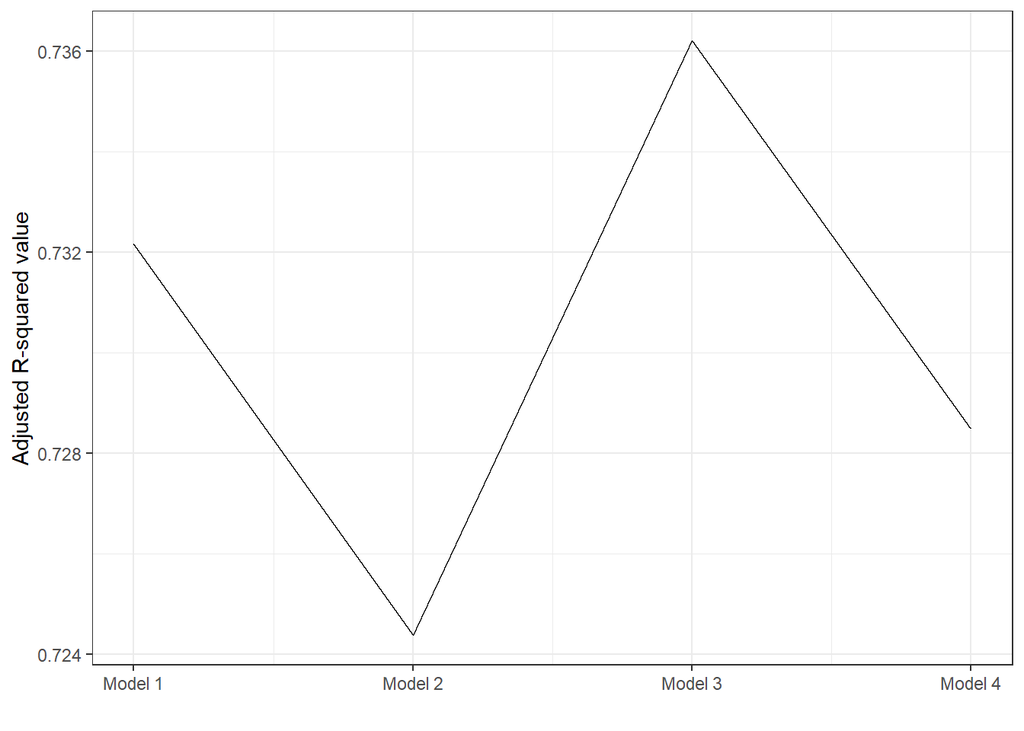

```r
ModelFit <- tibble(model = c(1, 2, 3, 4),
                   R_square = c(summary(model1)$adj.r.squared,
                                summary(model2)$adj.r.squared,
                                summary(model3)$adj.r.squared,
                                summary(model4)$adj.r.squared))

ggplot(ModelFit, aes(x = model, y = R_square)) +
  geom_line() +
  scale_x_continuous(name = "",
                   breaks = breaks <- seq(1, 4, by = 1),
                   labels = paste("Model", breaks)) +
  scale_y_continuous(name = "Adjusted R-squared value") +
  theme_bw()
```

It looks like Model 3 is my best fitting model, but is pretty close to Model 1.

```r
coeff_names <- c("Total Population" = "tot_pop",
                 "Median Age" = "med_age",
                 "Majority Race/Ethnicity Hispanic" = "majority_race_ethhispanic",
                 "Majority Race/Ethnicity Asian" = "majority_race_ethnh_asian",
                 "Majority Race/Ethnicity Black" = "majority_race_ethnh_black",
                 "No Majority Race/Ethnicity" = "majority_race_ethNone",
                 "Female Household No Children < 18 years" = "hh_female_nohusband_nochildrenunder18",
                 "Female Household Children < 6 years" = "hh_female_nohusband_childrenunder6yr",
                 "Husband Wife Household Children < 6 years" = "hh_husband_wife_fam_childrenunder6yr",
                 "Male Partners Household Children < 18 years" = "hh_unmarriedmale_malepartner_childrenunder18",
                 "Female Partners Household Children < 18 years" = "hh_unmarriedfemale_femalepartner_childrenunder18",
                 "Interaction:\nFemale Household No Children < 18 years and Median Age" = "med_age:hh_female_nohusband_nochildrenunder18",
                 "Interaction:\nFemale Household Children < 6 years and Median Age" = "med_age:hh_female_nohusband_childrenunder6yr")

export_summs(model1, model3,
             error_format = "(p = {p.value})",
             error_pos = "same",
             model.names = c("Initial model", "Preferred model"),
             coefs = coeff_names)
```

|  | Initial model | Preferred model |
| --- | --- | --- |
| Total Population | -0.00 (p = 0.05) | -0.00 (p = 0.07) |
| Median Age | 0.02 *** (p = 0.00) | 0.01 *** (p = 0.00) |
| Majority Race/Ethnicity Hispanic | -0.06 * (p = 0.05) | -0.06 * (p = 0.03) |
| Majority Race/Ethnicity Asian | -0.34 *** (p = 0.00) | -0.34 *** (p = 0.00) |
| Majority Race/Ethnicity Black | -0.02 (p = 0.49) | -0.02 (p = 0.60) |
| No Majority Race/Ethnicity | -0.02 (p = 0.26) | -0.02 (p = 0.45) |
| Female Household No Children < 18 years | 0.00 ** (p = 0.00) | -0.00 (p = 0.24) |
| Female Household Children < 6 years | -0.00 *** (p = 0.00) | 0.01 (p = 0.12) |
| Husband Wife Household Children < 6 years | 0.00 *** (p = 0.00) | 0.00 *** (p = 0.00) |
| Male Partners Household Children < 18 years | 0.01 * (p = 0.04) | 0.01 (p = 0.05) |
| Female Partners Household Children < 18 years | 0.01 ** (p = 0.01) | 0.01 ** (p = 0.00) |
| Interaction: Female Household No Children < 18 years and Median Age |  | 0.00 (p = 0.06) |
| Interaction: Female Household Children < 6 years and Median Age |  | -0.00 * (p = 0.03) |
| N | 197 | 197 |
| R2 | 0.75 | 0.75 |
| *** p < 0.001; ** p < 0.01; * p < 0.05. |  |  |

### Visualizing Regression Results

I think Model 1 is actually my preferred model, looking at the statistical significance for my variables. I am going to graph Model 1:

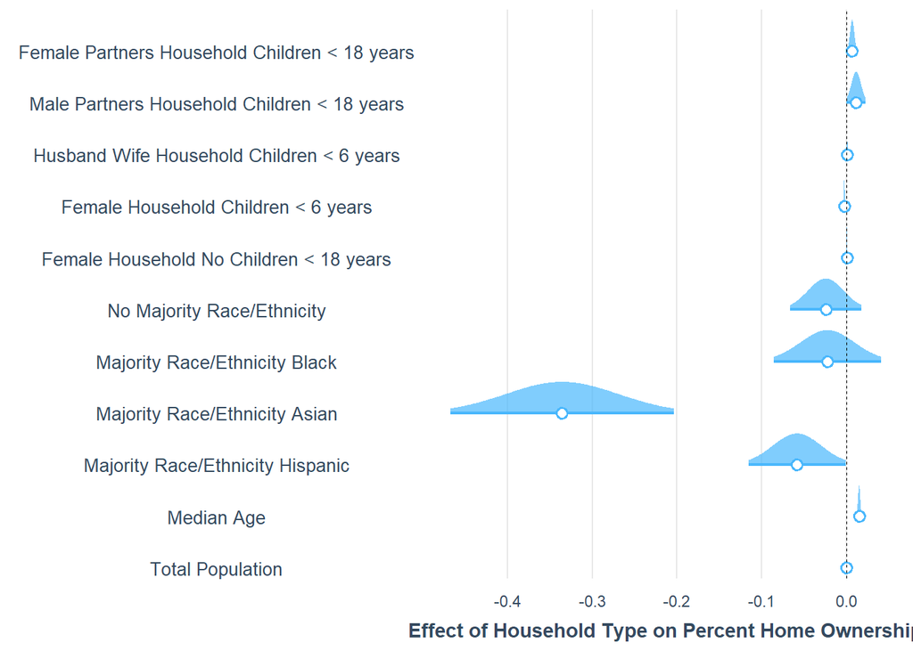

```r
coeff_desc <- c("Total Population" = "tot_pop",
                 "Median Age" = "med_age",
                 "Majority Race/Ethnicity Hispanic" = "majority_race_ethhispanic",
                 "Majority Race/Ethnicity Asian" = "majority_race_ethnh_asian",
                 "Majority Race/Ethnicity Black" = "majority_race_ethnh_black",
                 "No Majority Race/Ethnicity" = "majority_race_ethNone",
                 "Female Household No Children < 18 years" = "hh_female_nohusband_nochildrenunder18",
                 "Female Household Children < 6 years" = "hh_female_nohusband_childrenunder6yr",
                 "Husband Wife Household Children < 6 years" = "hh_husband_wife_fam_childrenunder6yr",
                 "Male Partners Household Children < 18 years" = "hh_unmarriedmale_malepartner_childrenunder18",
                 "Female Partners Household Children < 18 years" = "hh_unmarriedfemale_femalepartner_childrenunder18")


plot_coefs(model1,
           coefs = coeff_desc,
           plot.distributions = TRUE,
           rescale.distributions = TRUE) +
  scale_x_continuous(name = "Effect of Household Type on Percent Home Ownership")
```